# Exploratory Analysis

## Causes of Death in the United States

### Authors

Robert Bonglamphone (bonglrob@uw.edu), Evelyn Sotelo, Bianca Flores

### Date

Winter 2023

### Abstract

“Our main question is how the causes of death relate to the particular area that the death occurs in. This question is important because it gives us insight into problems within these regions that can be focused on to improve the future of death rates. To address the question, we will create data plots that allow us to analyze particular areas in which certain causes of death or most prominent.”We are concerned with the prominent reasons for death, because it can allow users of this data to treat cautionary problems.

### Keywords

Death, population, United States, 1999-2017

### Introduction

We will be doing our project on the leading cause of death in the United States.

Some questions that we are interested in is: Which states/regions have the most deaths per capita?

I think this is worth exploring because different areas may have different main causes.

Another question we’re interested in is: How are governments and organizations addressing the leading causes of death and what more can be done?

If we find that there is a reason for a majority of the deaths and there is a way to maybe prevent it, we could see if the governments are doing their part to lower the rates.

Lastly: What is the economic impact of the leading causes of death on individuals, families, and society?

I think this is also an important question because one reason that we could assume is that some people can’t afford healthcare. Hypothetically if that is the case, what could we do to help and assist those who don’t have access to hospitals/ can’t afford it. These are just a few questions but I think that there are more that we could add and go further into.

### Related Work

“The government spends more than $1 trillion on health per year” (USAFacts). The US government has a vested interest in the public health sector. This means gathering insights and understanding of the death rate among different populations can impact policy and funding. If one state has a higher death rate for vehicle accidents, one can conclude that there could be something wrong with transportation and infrastructure or there is a population shift where older populations are moving there. States also implement different health services, so if there is a decrease in suicides for one state over time, there could use a similar policy that other states can consider using.

In recent times, COVID was a leading cause of death, but the numbers allow us to understand the true impact of the disease. “The year 2021 saw the highest death rate since 2003, with increases in many leading causes of death, including COVID-19 and unintentional injuries” (Provisional mortality data - united states, 2021). When the data is presented like so, it shows how necessary quarantine and certain health measures needed to be made to tackle the disease.

Our topic is death in the united states, which connects to certain health issues. We chose this topic to help contribute to the further understanding of death and why it happens in the united states. There have been many different research papers revolving around death in the united states. In a profile paper titled “A Profile of Death and Dying in America”, researchers wrote about death and everything that goes into it for example when it typically happens, the causes, how its viewed, and certain preventions. The overall message that we learn from this paper is that all the aspects of death keep changing and will continue to change.

“Provisional Mortality Data - United States, 2021.” Centers for Disease Control and Prevention, Centers for Disease Control and Prevention, 28 Apr. 2022, https://www.cdc.gov/mmwr/volumes/71/wr/mm7117e1.htm.

USAFacts. “Most Common Causes of Death in the US.” USAFacts, USAFacts, 22 Sept. 2020, https://usafacts.org/articles/americans-causes-of-death-by-age-cdc-data/.

Field, Marilyn J, and Christine K Cassel. “2 a Profile of Death and Dying in America - NCBI Bookshelf.” National Center for Biotechnology Information, 1997, https://www.ncbi.nlm.nih.gov/books/NBK233601/.

### The Dataset

> Where did you find the data?

The data was found in data.gov at https://catalog.data.gov/dataset/nchs-leading-causes-of-death-united-states

> Who collected the data?

The National Center for Health Statistics (NCHS), which is a US government agency and a unit of the Centers for Disease Control and Prevention (CDC).

> How was the data collected or generated?

Data is collected from the death certificates of US residents. Each death certificate identifies the cause of death and the state from which it was filed under.

> Why was the data collected?

The data was collected to study the US population for the interest of public health. Statistics on death rates and disease can pick out patterns and formulate opinions to adopt relevant policies and health guidelines.

> How many observations (rows) are in your data?

There are 10868 observations.

> How many features (columns) are in the data?

There are 6 features in the data.

> What, if any, ethical questions or questions of power do you need to consider when working with this data?

How are populations that are excluded from this data (e.g. undocumented peoples) affected when this data is used to determine policy for health services?

> What are possible limitations or problems with this data? (at least 200 words)

Since the data is based on death certificates of US citizens, it does not fully represent the population as a whole. There are misfiled death certificates, undocumented residents, and nationals who are living abroad. Fetal deaths are also excluded from the dataset. We can’t rely on the data on full confidence, but we can make good guesses on the death rates.

The death rate is also not an accurate predictor of the number of deaths because it’s based on the US Census. Between 1999 and 2010, the 2000 US Census is used to calculate the death rate. After 2010, the 2010 US Census is used instead. The US Census is conducted once every decade, so the data collected will also not be representative of the US population. This runs into the same problem as relying on death certificates for information. As a result, this creates a feedback loop where inaccurate data will be used to compile statistics that will have a big margin of error.

Another problem with the dataset is that data collected from the death certificate will be based on the main underlying cause of death determined by the practicing medical examiner. Inaccurate diagnosies can make their way into the data and mask the true cause of death. This could lead to conclusions where some deaths are ocurring more than others.

### Implications

Our primary research question is what is the leading cause of death in the United States? By answering this question, we can help with the conduction of research and help minimize future casualties that could occur because of these causes. For example, if the leading cause is a disease, scientists can be aware of this, and then they will know that there is a need for more research on this disease so we could potentially help cure or better treat it so the death toll can decrease.

Another research question our project can help answer is what is each state’s top cause of death? By knowing the leading cause of death in each individual state, we can potentially help resolve more than just health issues in that state. For example, if the reason is affected by an environmental factor, we could focus more on helping the environmental problems in that state to help decrease the death count. The same could go for any deaths caused by socioeconomic issues.

### Limitations & Challenges

The death data set limits what we can do for our project. The causes of death can be more difficult to keep track of. This can also be a limitation in terms of grouping the data into categories, such as groupings of similar deaths. One detail that is given within the data set is the deaths regarding heart disease. The category of deaths related to heart disease is listed within its own category, and is in a chronological order. Other categories contain the deaths caused by stroke, and by cancer. The data within these categories are somewhat unorganized other than their intial groupings. This can be the main limitation to what we can do for our group project.

Another possible limitation can be how we include the age adjusting rates. It is provided in order to make fairer comparisons between the deaths listed, based on the differences between groups during the general time of their deaths. This may make the data more confusing when making comparisons.

### Summary Information

In the US, from 1999-2017, the highest death count reported was 2813503 deaths. In 2017, the leading cause of death in the US is Heart disease. In the same year, the state with the highest death count is California with a death count of 268189. The state with the highest age adjusted death rate is District of Columbia with 1087.3 deaths per 100,000 peoples based on the US 2000 Census.

### Table

```
## # A tibble: 6 × 5
## # Groups:   Year, State [6]
##    Year Cause.Name    State                Deaths Age.adjusted.Death.Rate
##   <int> <chr>         <chr>                 <int>                   <dbl>
## 1  2017 Heart disease Alabama               13110                    223.
## 2  2017 Heart disease Arizona               12398                    142.
## 3  2017 Heart disease Arkansas               8270                    224.
## 4  2017 Heart disease California            62797                    143.
## 5  2017 Heart disease Connecticut            7138                    142.
## 6  2017 Heart disease District of Columbia   1284                    190.
```

We included this table to demonstrate how each of the state compare to one another in death count. Since the data spans from 1999-2017, we can see trends on how what are the leading causes of death in each state. At a glance, heart disease is still a dominant leading cause of death in the United States, with a majority of states confirming that.

### Map Chart: Leading Causes of Death in US

There are many causes of death in the United States, but my focus was to see what was the main cause of death. Specifically, the audience should be able to draw a quick comparison between states and how they differ. Therefore, a map of the United States was the perfect fit. Also, there was only one of 2 causes of death that a state can be classified under, so a state would be the color of the leading cause of death that it represents.

The map shows the top cause of death in the United States per state in 2017. Either a state’s population main cause of death would be between heart disease and cancer. Overwhelmingly, heart disease is the main cause of the death between all the states. Roughly 1/4 of the states’ main cause of death was cancer.

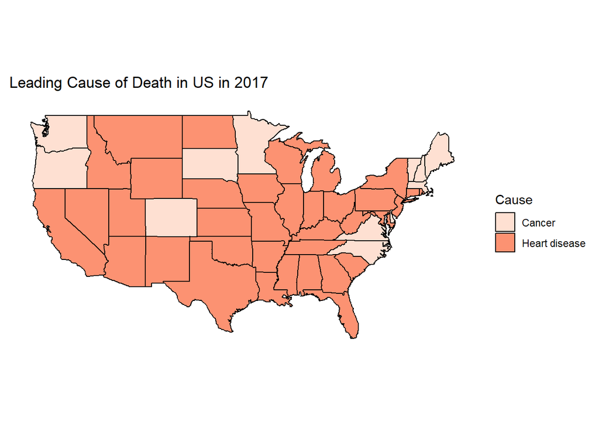

[figure not shown]

### Bar Chart: Top 10 Leading Causes of Death in 2017

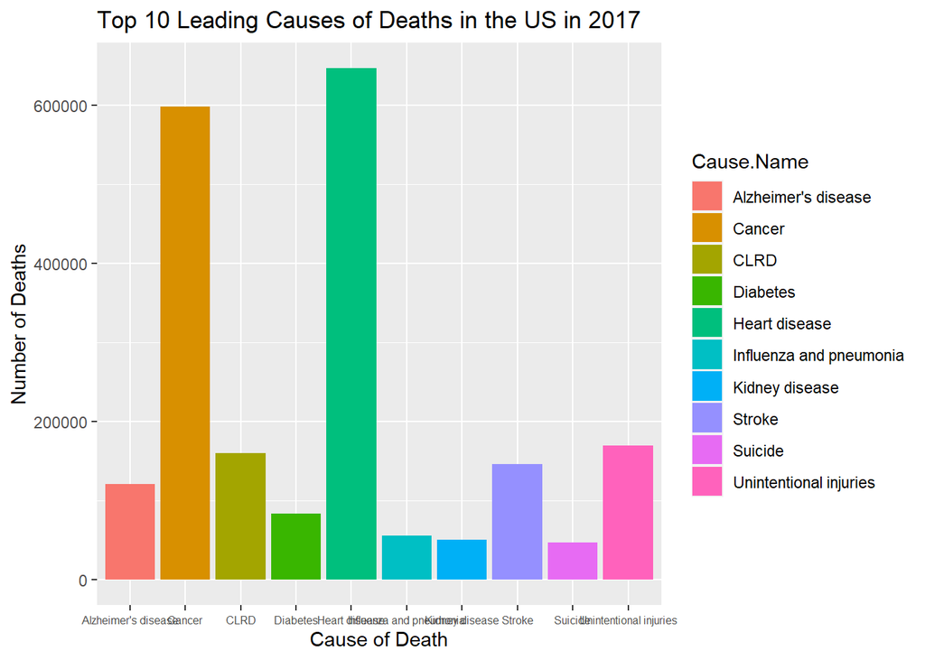

### Purpose

We wanted to show the top 10 causes of death in 2017 visually, so we made a bar graph. By using a bar graph to display this data, we could see the difference in bar length between each cause.

### Insights

- The top cause of death is heart disease at more than 600,000 deaths.
- The lowest cause of death is suicide at more than 47,000 deaths.